# Faire l’histoire de l’économie à l’aide des Large Language Models

Aurélien Goutsmedt

Midis de la Recherche

9 février 2026

### [One Sentence at a Time: A Computational History of Rationality in Economics](https://osf.io/preprints/socarxiv/38na2_v1) - Delcey, Goutsmedt and Truc

- Utiliser des méthodes textuelles pour saisir l’évolution des usages et des significations de la rationalité :
  - Une préoccupation de longue date pour les historiens de l’économie ;
  - Un concept complexe et en évolution.
- Construire une méthode visant à :
  - explorer des corpus très vastes (des millions de phrases) ;
  - prendre en compte le contexte historique ;
  - permettre l’exploration interprétative des résultats.

## Représenter numériquement un texte

Table 1: Exemple de corpus

| id | texte | année | variable_2 |
| --- | --- | --- | --- |
| 1 | I love markets | 1950 | ... |
| 2 | Viva la revolucion | 1950 | ... |
| 3 | In markets, we trust | 1955 | ... |
| ... | ... | ... | ... |

A «l’oeil nu», il est facile de voir que le premier et le troisième documents sont sémantiquement plus proches l’un de l’autre que du second. Comment un ordinateur peut-il le repérer ?

## Bag-of-words

- La méthode la plus simple consiste à compter la fréquence des unités textuelles choisies (mots, n-grammes, etc.) dans chaque document.

**Bag-of-words - Mode d’emploi**

- Etant donné un corpus $C$ avec $D$ documents…
- … et un vocabulaire $V$ termes, la liste des mots uniques du corpus…
- la représentation «bag-of-words» de $C$ est une matrice $W$ de dimension $D \times V$.
- Chaque entrée $w_{d,v}$ est le nombre d’occurrences du terme $v$, $v \in \{1, \ldots, V\}$ dans le document $D$

## Un exemple

Table 2: Exemple de corpus

| id | texte | année | variable_2 |
| --- | --- | --- | --- |
| 1 | I love markets | 1950 | ... |
| 2 | Viva la revolucion | 1950 | ... |
| 3 | In markets, we trust | 1955 | ... |
| ... | ... | ... | ... |

Table 3: Exemple d’une matrice bag-of-words

| id | i | love | markets | la | revolucion | viva | in | trust | we |
| --- | --- | --- | --- | --- | --- | --- | --- | --- | --- |
| 1 | 1 | 1 | 1 | 0 | 0 | 0 | 0 | 0 | 0 |
| 2 | 0 | 0 | 0 | 1 | 1 | 1 | 0 | 0 | 0 |
| 3 | 0 | 0 | 1 | 0 | 0 | 0 | 1 | 1 | 1 |

**Avantages**

- Simple à construire et à interpréter.
- Bonne approximation pour la similarité entre documents.

**Inconvénients**

- La matrice est très creuse et de haute dimension ($V \gg D$).
- On ignore l’ordre des mots et les variations de sens (synonymes, polysémie, etc.).

## Perte d’information

- Prenons les phrases suivantes :
  1. «People are rational.»
  2. «We assume *homo economicus*.»
  3. «Preferences are complete and transitive.»
  4. «Agents are profit-maximizers.»
- Ces phrases ne partagent pas un mot en commun mais ont pourtant un sens très proche.
- Idéalement, on veut une représentation capable de capturer cette similarité

## Word embeddings

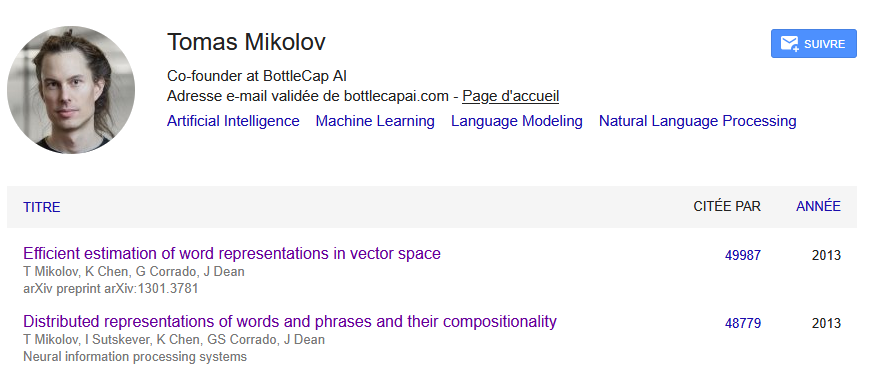

| Word | Dim1 | Dim2 | Dim3 | Dim4 | Dim5 |
| --- | --- | --- | --- | --- | --- |
| rational | 0.25 | 0.30 | 0.00 | -0.10 | 0.95 |
| agent | 0.20 | 0.28 | 0.05 | -0.05 | 0.80 |
| profit | 0.15 | 0.05 | 0.02 | 0.01 | 0.77 |
| markets | 0.10 | 0.12 | 0.03 | 0.00 | 0.60 |
| revolution | -0.30 | -0.25 | -0.10 | 0.40 | -0.20 |
| love | -0.40 | -0.35 | 0.50 | 0.20 | -0.60 |

- Les vecteurs sont entraînés sur une tâche de prédiction:
  - Prochain *token*; *token* «masqué»;
  - Les valeurs du vecteur correspondent aux paramètres «appris» par le réseau de neurones.

## Mesurer le «sens» de la rationalité: *embeddings* fixes et contextuels

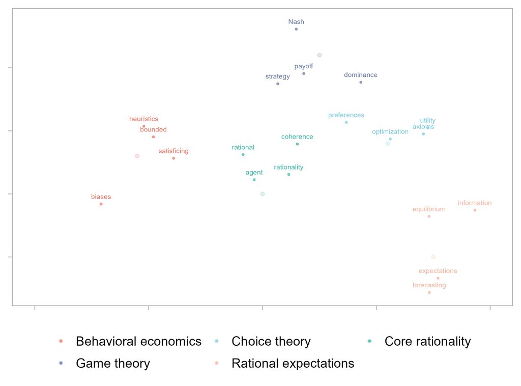

- La distance entre les vecteurs reflète la similarité sémantique.
- Métrique de distance : similarité cosinus.
- Premiers modèles : *embeddings* fixes (e.g., word2vec, GloVe).
- LLMs : *embeddings* contextuels (e.g., BERT, GPT, etc.).

## Qu’est-ce que BERT ?

- BERT (**Bidirectional Encoder Representations from Transformers**) = modèle de langage open source développé par Google en 2018.
  - Basé sur l’architecture **Transformer**: mécanismes d’**attention** pour traiter les séquences de texte.
  - **Attention** : mécanisme qui permet au modèle de se concentrer sur différentes parties du texte pour comprendre les relations entre les mots.

Alammar et Grootendorst (2024)

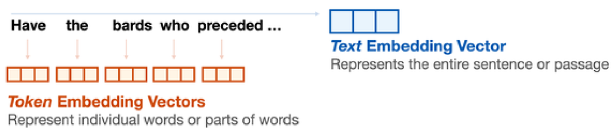

Rogers, Kovaleva, et Rumshisky (2021)

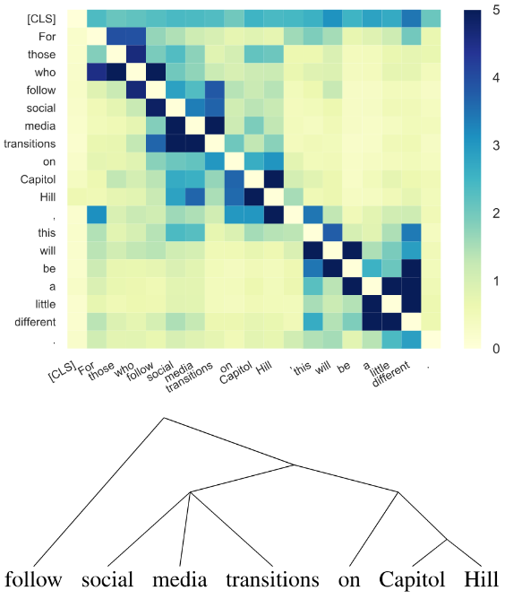

## BERT vs GPT : Quelles différences

### BERT — compréhension (encoder, bidirectionnel)

- Objectif d’entraînement : Masked Language Modeling (MLM) — prédire des tokens masqués.
- Architecture : Transformer *encoder* (bidirectionnel).
- Contexte : utilise le contexte gauche + droite.
- Usages typiques : classification, extraction d’entités, similarité de phrases (avec SBERT).
- Limites : pas optimisé pour la génération séquentielle.

### GPT — génération (decoder, autoregressif)

- Objectif d’entraînement : Language Modeling autoregressif — prédire le token suivant.
- Architecture : Transformer *decoder* (causal / unidirectionnel).
- Contexte : accès causal (gauche → droite).
- Usages typiques : génération de texte, complétions, dialogues, instruction-following.
- Limites : nécessite adaptation pour certaines tâches de compréhension.

## Sentence embeddings

On utilise *sentence-BERT*, un modèle LLM qui représente des **phrases** comme des vecteurs et est optimisé pour les tâches de similarité sémantique.

Table 4: Phrases proches de «Economic agents are supposed to be rational.»

| year | sentence | similarity |
| --- | --- | --- |
| 1950 | Basically, for Professor Hicks, as for Jevons and Marshall, economic decisions are made by an abstract calculating machine. | 0.706 |
| 1950 | Modern civilization is lopsided in its emphasis on rationality, especially on economic rationality. | 0.700 |
| 1950 | Rational behavior means conduct motivated by the goal of maximization of money income, wealth and economic advantages. | 0.700 |
| 1975 | Rationality and Irrationality in Economics. | 0.750 |
| 1975 | Such agents are assumed to act rationally and exclusively on the basis of market given information. | 0.721 |
| 1975 | In Marshallian analysis, economic agents are conceived to be not so much rational as reasonable. | 0.710 |
| 2000 | Agents have rational expectations. | 0.771 |
| 2000 | Rational in the narrow economic sense of profit maximizing. | 0.768 |
| 2000 | Actors who operate in an economy are generally rational in the sense that they are interested in improving their individual position. | 0.768 |

## Mesurer polysémie & évolution sémantique

Giulianelli, Tredici, et Fernández (2020)

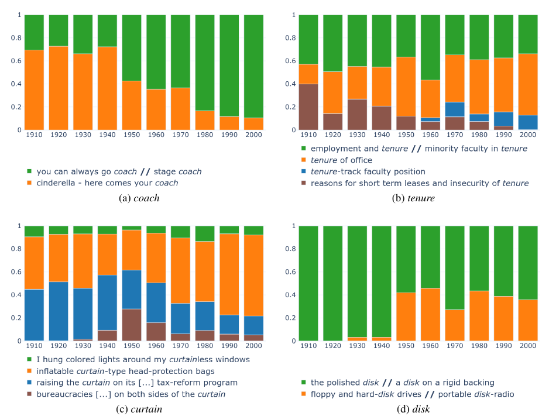

## Et l’histoire dans tout ça ?

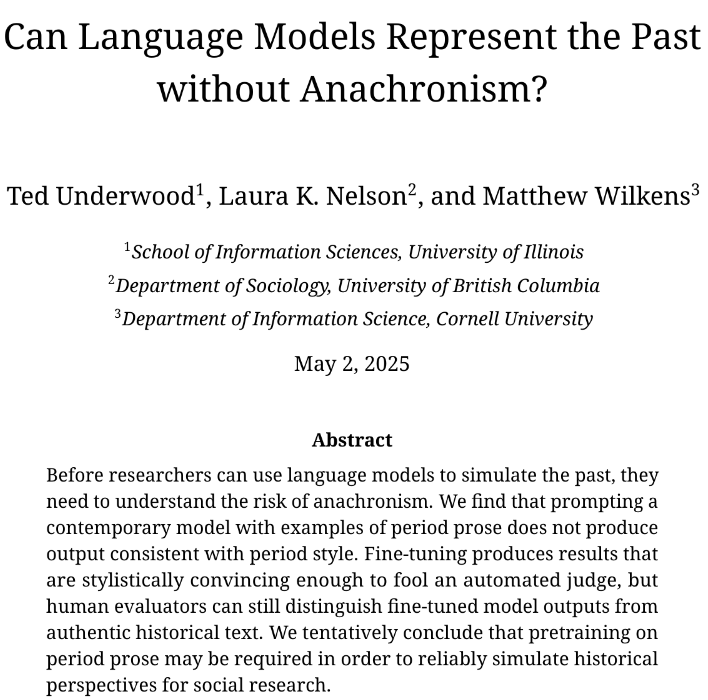

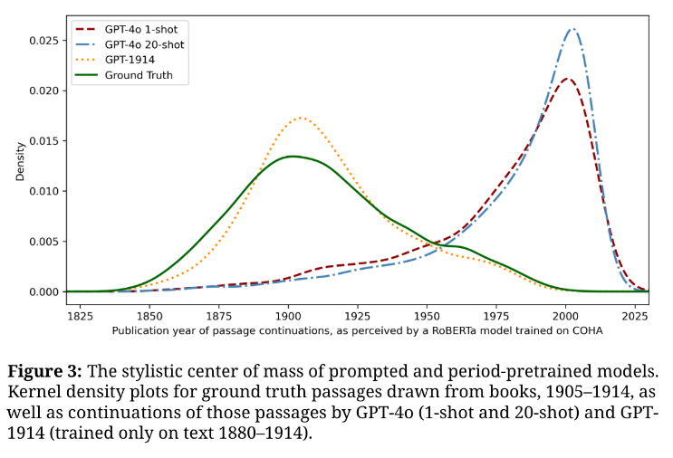

## Adaptation au domaine

- **pretraining** : les modèles sont entrainés sur des très grands corpus ; les paramètres obtenus peuvent être utilisés pour d’autres tâches = *transfer learning*.
  - … mais les modèles sont entraînés sur des corpus **généraux** et **récents**.
- possibilité de réentraîner les modèles sur un corpus plus spécifique, pour adapter les paramètres à un domaine particulier.
  - … mais nécessite des ressources importantes pour l’**adaptation** au domaine…
- Développement de modèles de langage spécialisés pour l’histoire, comme *HistBERT* (Qiu et Xu 2022) et au climat *ClimateBERT* (Webersinke et al. 2022).

## Stratégie empirique adoptée

1. Calculer des «vecteurs représentatifs» pour le concept de rationalité.
   1. Sélectionner toutes les phrases contenant les mots «rational» ou «rationality».
   2. Calculer l’*embeddings* de ces phrases.
   3. Calculer une moyenne mobile de ces vecteurs = un «vecteur représentatif» par an.
2. Extraire les phrases similaires dans le corpus à partir de ce vecteur.
   1. Pour chaque année, calculer la similarité cosinus entre le «vecteur représentatif» et les 61M d’*embeddings* de phrases du corpus.
   2. Sélectionner le top 1% des phrases les plus similaires pour chaque année
3. Grouper ces phrases en clusters.
   1. Regrouper les phrases par décennie.
   2. Calculer les centroïdes des clusters pour fusionner les clusters similaires en méta-clusters.

## Méthodes non-supervisées & interprétation

- **Non-supervisé** : Utilisation d’algorithme pour identifier des structures dans les données
  - Produire des catégorisations qui ne sont pas données à priori par le ou la chercheur·se
  - (Pas possible avec un chatbot…)
- **Interprétation** : comprendre pourquoi l’algorithme a regroupé certaines phrases ensemble, et pas d’autres.
- Non-supervisé ne veut pas dire sans moyen de varier composition, taille et nombre de catégories
  - Implique de tester différents jeux de paramètres
- Mais que signifient ces catégories ? Pourquoi certains documents sont groupés ensemble ?
  - Nécessite un travail d’interprétation qualitative
  - Nécessite un travail de visualisation adapté, pour faire apparaître ce qui caractérise ces catégories, ce qui les lie et les différencie

## Utiliser une application interactive pour explorer les résultats

https://019adac8-81d4-aa0e-808c-08861c261fd2.share.connect.posit.cloud/

## Bibliographie

Alammar, Jay, et Maarten Grootendorst. 2024. *Hands-On Large Language Models: Language Understanding and Generation*. 1ʳᵉ éd. Beijing Boston Farnham: O’Reilly Media.

Giulianelli, Mario, Marco Del Tredici, et Raquel Fernández. 2020. « Analysing Lexical Semantic Change with Contextualised Word Representations ». arXiv. https://arxiv.org/abs/2004.14118.

Qiu, Wenjun, et Yang Xu. 2022. « HistBERT: A Pre-trained Language Model for Diachronic Lexical Semantic Analysis ». https://doi.org/10.13140/RG.2.2.14905.44649.

Rogers, Anna, Olga Kovaleva, et Anna Rumshisky. 2021. « A Primer in BERTology: What We Know about How BERT Works ». *Transactions of the Association for Computational Linguistics* 8: 842‑66. https://doi.org/10.1162/tacl_a_00349.

Webersinke, Nicolas, Mathias Kraus, Julia Anna Bingler, et Markus Leippold. 2022. « ClimateBert: A Pretrained Language Model for Climate-Related Text ». arXiv. https://doi.org/10.48550/arXiv.2110.12010.